# MATLAB

MATLAB (MATrix LABoratory) is a high-level programming language and interactive environment for algorithm development, data visualization, data analysis, and numeric computation. Core strengths of the system include rapid development, powerful built-in functionality and extensive application-specific functionality provided by both official toolboxes and and user-contributed code.

MATLAB contains several different parts:

- Desktop Tools and Development Environment - This part of MATLAB is the set of tools and facilities that help you use and become more productive with MATLAB functions and files. Many of these tools are graphical user interfaces. It includes: the MATLAB desktop and Command Window, an editor and debugger, a code analyzer, and browsers for viewing help, the Workspace, and folders.
- Mathematical Function Library - This library is a vast collection of computational algorithms ranging from elementary functions, like sum, sine, cosine, and complex arithmetic, to more sophisticated functions like matrix inverse, matrix eigenvalues, and fast Fourier transforms.
- The Language - The MATLAB language is a high-level matrix/array language with control flow statements, functions, data structures, input/output, and object-oriented programming features. It allows both "programming in the small" to rapidly create quick programs you do not intend to reuse. You can also do "programming in the large" to create complex application programs intended for reuse.
- Graphics - MATLAB has extensive facilities for displaying vectors and matrices as graphs, as well as annotating and printing these graphs. It includes high-level functions for two-dimensional and three-dimensional data visualization, image processing, animation, and presentation graphics. It also includes low-level functions that allow you to fully customize the appearance of graphics as well as to build complete graphical user interfaces on your MATLAB applications.
- External Interfaces - The external interfaces library allows you to write C and Fortran programs that interact with MATLAB. It includes facilities for calling routines from MATLAB (dynamic linking), for calling MATLAB as a computational engine, and for reading and writing MAT-files.

# References

http://www.mathworks.com/help/matlab/

http://www.facstaff.bucknell.edu/maneval/help211/exercises.html

A MATLAB Tutorial - Ed Overman, Department of Mathematics, The Ohio State University

Introduction to MATLAB for engineering students, David Houcque, Northwestern University

MATLAB, An Introduction, IT Services, University of Oxford

# Summary

Revise vector and matrices data types

Data types:

- Strings
- Cell arrays
- Structures
- Tables

Symbolic manipulation

Flow control of programs:

- if
- for
- while

Reading and Writing to files

Visualization of data

# MatLab data types

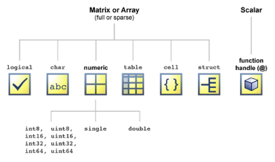

http://www.mathworks.com/help/matlab/matlab_prog/fundamental-matlab-classes.html

# Definitions: Matrices and Vectors

## Matrices

- The most basic MATLAB data structure is the matrix: a two-dimensional, rectangular structure capable of storing multiple elements of data in an easily accessible format.
- The elements of a matrix must all be of the same data type (numeric, character, logical etc.), but here we will focus on numeric matrices.
- MATLAB uses two-dimensional matrices to store single elements and linear series of elements as well. In these cases, the dimensions are 1-by-1 and 1-by-N (or N-by-1) respectively. For numeric data, special meaning is sometimes attached to 1-by-1 matrices, which are scalars, and to matrices with only one row or column, which are vectors.
- MATLAB also supports data structures that have more than two dimensions. These data structures are referred to as multidimensional arrays, and indeed the matrix is really a special case of an n-dimension array, with n=2.

## Vectors

In MATLAB a vector is a matrix with either one row or one column. The distinction between row vectors and column vectors is essential. Many programming errors are caused by using a row vector where a column vector is required, and vice versa.

# Vectors

x=ones(1,5)

y=zeros(5,1)

x=linspace(1,5,10)

y=logspace(1,4,4)

help linspace

x=zeros(1,5);

y=x;

x=[3 2 3 7 5]

x(1)

x(0)

x(6)

x(3)

y=1:5'

y=(1:5)'

x=1:5

x=1:2:10

xbegin=1; xend=10; nx=5; dx=(xend-xbegin)/(nx-1);

x1 = linspace(xbegin,xend,nx);

x2 = xbegin:dx:xend;

y1=x1(3:4)

y1(2)=3

x1

y1(5)=4

x=[3 5]

x=[x x]

x=1:5

x+x

x=x+x

x=1:5

x=x*0.5

y=1:5

x+y

x*y

x*y'

x=10:-2:0

x=7:4

x=1:10;

max(x)

min(x)

sum(x)

prod(x)

mean(x)

std(x)

x=[1 23 5 17 8 3]

x<4

x(x<4)

x=[1 2 3]

y=[2 3 4]

x*y

x.*y

# Matrices

A = [6 3 2 8; 5 1 3 7; 1, 6, 7, 2;4,5,4,1]

[7 -2 +5], [7 - 2 + 5], [7, - 2, +5]

B = [6 3 2 8; 5 1 3]

ones(2,5)

zeros(2,2)

rand(2,2)

A = [1 2;3 4]

B = [5 6;7 8]

A+B

A-B

C=[A,B]

D=[A;B]

B = [5 6;7 8;9 10]

C=[A,B]

D=[A;B]

E=cat(1,A,C)

E=vertcat(A,C)

F = [1 2 3;4 5 6];

G = repmat(F,2,3)

A = [6 3 2 8; 5 1 3 7; 1, 6, 7, 2;4,5,4,1]

A(3,2)

A(7)

linearindex = sub2ind(size(A),3,2)

A(2,1:3)

A(1:3:16)

A(2:3,1:3)

A(2,2:end)

A(2,:)

A([1,4,9])

L = A<5

A(L)

A(A<5)

A(L) = 0

size(A)

length(A)

numel(A)

islogical(A)

isnumeric(A)

isvector(A)

isscalar(A)

ismatrix(A)

isempty(A)

F = [1,2,3;4,5,6];

F(1,5)

F(1,5)=3

F = [1,2,3;4,5,6];

F(1:2,5:6) = 8

F(:,6) = []

F = [1,2,3;4,5,6]

fliplr(F)

transpose(F)

reshape(F,3,2)

circshift(F,1,2)

A = [6 3 2 8; 5 1 3 7; 1, 6, 7, 2;4,5,4,1]

sort(A,1)

sort(A,2)

sort(A,2,'descend')

sortrows(A,2)

max(A)

max(A,[],2)

[y,I]=max(A,[],2)

max([4 5; 0 1],[1 2;3 4])

mean(A,1)

mean(A,2)

# Strings

str = 'Character strings is a minor component of MATLAB'

length(str)

str='ABCDEF'

str*1

str(2:4)

str2 = [str 'added']

x = linspace(0, 2*pi, 100)'

c1 = 2

c2 = -3

y = c1*sin(x) + c2*cos(x)

s = [ num2str(c1), '*sin(x) + ' , num2str(c2), '*cos(x)' ]

str=['abc';' def']

str=['abc';'def']

size(str)

str(2,2)

str=(' 1234 567 ')

length(str)

strtrim(str)

length(strtrim(str))

sprintf('%15.5f',1/1e-10)

sprintf('%d',round(pi))

sprintf('The array is %dx%d.',2,3)

# Cell Arrays and Structures

C = {2+3i, 'first' ; [1 2 3]','second'}

D{1,1}=2+3i

D{1,2}='first'

D{2,1}=(1:3)'

D{2,2}=[1 2;3 4]

D(2,1)+2

D{2,1}+2

class(D(1,1))

class(D{1,1})

D{2,2}(2,1)

D{2,1}^2

D{2,1}.^2

D{2,1}(3)

D{1,2}(1)

Cs.scalar = 2+3i

Cs.text = 'first'

Cs.vector = [1 2 3]'

Cs.matrix = [1 2;3 4]

Cs.vector

Cs.text

Cs.matrix(1,2)

sf = 'matrix'

Cs.(sf)=[3 4;5 6]

Cs.matrix

fieldnames(Cs)

## Exercise #1

# Tables

table is a data type for collecting heterogeneous data and metadata properties such as variable names, row names, descriptions, and variable units, in a single container. Each variable in a table can have a different data type, but must have the same number of rows.

load patients

whos

T = table(Gender,Smoker,Height,Weight);

T.ID = randi(1e4,100,1);

T(1:5,:)

summary(T)

Tnew = T(1:5,:)

Tnew = Tnew(:,2:end)

size(T)

T.Properties.RowNames = LastName;

T(1:5,:)

size(T)

Tnew = T({'Smith','Johnson'},:)

Tnew = T('Johnson',{'Height','Weight'})

T.BMI = (T.Weight*0.453592)./(T.Height*0.0254).^2;

T(1:5,:)

T(T.BMI>24,:)

tf=(T.Smoker==false);

T.BMI(tf)

%Sort rows by specific columns

T = sortrows(T,'RowNames')

T = sortrows(T,'Height')

%Setup some metadata

T.Properties.VariableUnits{5}='kg/m^2';

T.Properties.VariableDescriptions{5}='Body Mass Index';

T.Properties.VariableUnits{'BMI'}='kg/m^2';

T.Properties.VariableDescriptions{'BMI'}='Body Mass Index';

%Create a two column variable

T.BloodPressure = [T.Systolic T.Diastolic];

%You can also reorder based on the names

varnames = T.Properties.VariableNames;

others = ~strcmp('Gender',varnames);

varnames = [varnames(others) 'Gender'];

T = T(:,varnames);

## Exercise #2

# Some useful manipulation of data

Create a csv file (messy.csv) containing:

A,B,C,D,E

afe1,3,yes,3,3

egh3,.,no,7,7

wth4,3,yes,3,3

atn2,23,no,23,23

arg1,5,yes,5,5

jre3,34.6,yes,34.6,34.6

wen9,234,yes,234,234

ple2,2,no,2,2

dbo8,5,no,5,5

oii4,5,yes,5,5

wnk3,245,yes,245,245

abk6,563,,563,563

pnj5,463,no,463,463

wnn3,6,no,6,6

oks9,23,yes,23,23

wba3,,yes,NaN,14

pkn4,2,no,2,2

adw3,22,no,22,22

poj2,-99,yes,-99,-99

bas8,23,no,23,23

gry5,NA,yes,NaN,21

T = readtable('messy.csv','TreatAsEmpty',{'.','NA'})

summary(T)

TF = ismissing(T,{'' '.' 'NA' NaN -99});

T(any(TF,2),:)

T = standardizeMissing(T,-99)

T2 = fillmissing(T,'previous')

T3 = rmmissing(T)

T3 = sortrows(T2,{'C','A'},{'descend','ascend'})

## Exercise #3

# Symbolic manipulation

% Differentiation

syms x y

f = x^2 + 3*y;

subs(f,y,1)

subs(f,y,[1 2 3])

syms x

f = x^2;

diff(f)

syms x y

f = x^2 + 3*y;

diff(f,x)

diff(f,x,2)

% Integration

int(f)

int(f,1,10)

% Solve equations

syms x

solve(x*(x-2))

solve(x^3 - 6*x^2 == 6 - 11*x,x)

syms x y z

[x, y, z] = solve(z == 4*x, x == y, z == x^2 + y^2)

% Simplify

simplify(sin(x)^2 +cos(x)^2)

# Control flow and operators

MATLAB is also a programming language. Like other computer programming languages, MATLAB has some decision making structures for control of command execution. These decision making or control flow structures include for loops, while loops, and if-else-end constructions. Control flow structures are often used in script M-files and function M-files.

MATLAB has four control flow structures: the if statement, the for loop, the while loop, and the switch statement.

## The ``if...end'' structure

if ... end

if ... else ... end

if ... elseif ... else ... end

The simplest form of the if statement is:

if expression

statements

end

Examples:

a=2;b=4;c=2;

discr = b*b - 4*a*c;

if discr < 0

disp('Warning: discriminant is negative, roots are imaginary');

end

discr = b*b - 4*a*c;

if discr < 0

disp('Warning: discriminant is negative, roots are imaginary');

else

disp('Roots are real, but may be repeated')

end

discr = b*b - 4*a*c;

if discr < 0

disp('Warning: discriminant is negative, roots are imaginary');

elseif discr == 0

disp('Discriminant is zero, roots are repeated')

else

disp('Roots are real')

end

Notes:

- elseif has no space between else and if (one word)
- no semicolon (;) is needed at the end of lines containing if, else, end
- indentation of if block is not required, but facilitate the reading.
- the end statement is required

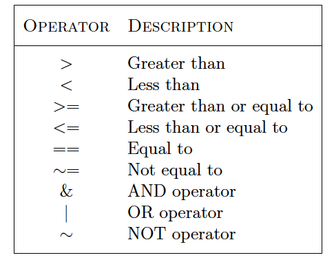

## Exercise #4

## The ``for...end'' loop

for variable = expression

statements

end

Examples:

for i=1:5

x=i*i

end

n=5;

out=n;

for i=n-1:-1:2

out=out*i;

end

disp(out)

## The ``while...end'' loop

while expression

statements

end

Example:

x = 1;

while x <= 10

x = 3*x

end

## Switch

switch switch_expression

case case_expression

statements

case case_expression

statements

...

otherwise

statements

end

Example:

n = input('Enter a number: ');

switch n

case -1

disp('negative one')

case 0

disp('zero')

case 1

disp('positive one')

otherwise

disp('other value')

end

Others:

- The break statement. A while loop can be terminated with the break statement, which passes control to the first statement after the corresponding end. The break statement can also be used to exit a for loop.
- The continue statement can also be used to exit a for loop to pass immediately to the next iteration of the loop, skipping the remaining statements in the loop.
- Other control statements include return, continue, etc..

## Exercise #5

# Reading from and writing data to files

MATLAB is able to import and export data from many different file types, and different import and export methods are used for each type.

## MAT-Files

MAT-files are the default data storage file type in MATLAB. They are binary files that can store the variables in your current workspace for later use. MAT files use the .mat extension.

clear

x = 2

y = 5

save

x = 5000

load

whos -file matlab

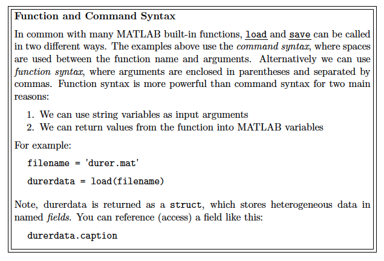

## Excel Files

[num,txt] = xlsread('hospital.xls');

[type, sheets] = xlsfinfo('USTreasury.xls')

[num,txt] = xlsread('USTreasury.xls',sheets {2})

[num,txt] = xlsread('USTreasury.xls',-1)

treasuries = importdata('USTreasury.xls')

xlswrite('testdata.xls', [12.7, 5.02, -98, 63.9, 0, -.2, 56])

d = {'Time','Temperature'; 12,98; 13,99; 14,97};

xlswrite('testdata2.xls', d, 1, 'E1')

## Text (ASCII) Files

x = magic(3);

save('temp.txt','-ascii')

load -ascii 'temp.txt'

mydata = importdata('headers.txt')

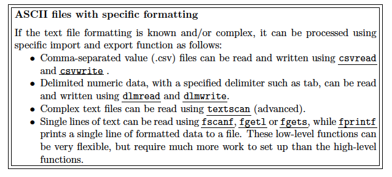

% write some variable length strings to a file

op = fopen('weekdays.txt','wt');

fprintf(op,'Sunday\nMonday\nTuesday\nWednesday\n');

fprintf(op,'Thursday\nFriday\nSaturday\n');

fclose(op);

## Binary Files

x = [1:3;4:6]

fid = fopen('temp.bin','w');

fwrite(fid, x);

fclose(fid);

fid = fopen('temp.bin');

y = fread(fid)

fclose(fid);

By default, fwrite writes the values from a matrix in column order as 8-bit unsigned integers (uint8). Also by default, fread reads a le 1 byte at a time, interpreting each byte as a uint8. fread creates a column vector output, with one element for each byte in the le. The values in the output vector are of type double (the default MATLAB numerical data type).

fid = fopen('temp.bin');

y = fread(fid, 4)

frewind(fid);

y = fread(fid, [2,2])

frewind(fid);

y = fread(fid, [2,inf])

fclose(fid);

xpi = pi*x

fid = fopen('xpi.bin','w+');

fwrite(fid, xpi, 'double');

frewind(fid);

y = fread(fid, [2,inf], 'double')

fclose(fid);

## Exercise #6

# Visualization of data

## Figures, Axes and Graphs

- A fi gure is a MATLAB window used for graphical display.
-  An axes is a 2D or 3D data space de fined within a figure.
-  A plot is any graphic display you can create within a figure window. Figures can contain any number of plots and each plot is created within an axes.
- A graph is a plot of data within an axes. Most plots are graphs.

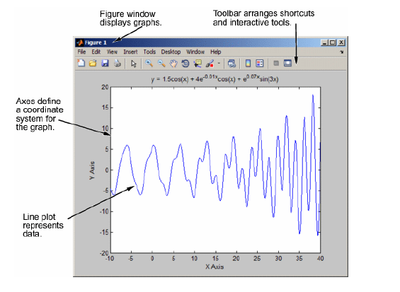

## Setting up figures

figure

subplot(2,3,4)

plot(rand(1,10))

subplot(2,4,5) % Overlap

% Avoiding overlap

subplot(2,1,2)

subplot(2,2,2)

subplot(4,4,1)

subplot(4,4,2)

subplot(4,4,5)

subplot(4,4,6)

close(1)

close all

subplot('position',[0.1, 0.4, 0.6 0.2]) % This follows subplot('Position',[left, bottom, width, height])

## Axes and axis

axes()

axes('Box','on','Color','r')

axis([0 0.5 0 0.8])

## Objects, Handles and Properties

close all

h1 = figure

h2 = axes('Box','on','Color','y')

% Get handles for the current figure and the current axes

gcf

gca

get(gcf)

get(gca)

get(h1,'Resize')

set(gca,'Color','k')

## Plotting Functions

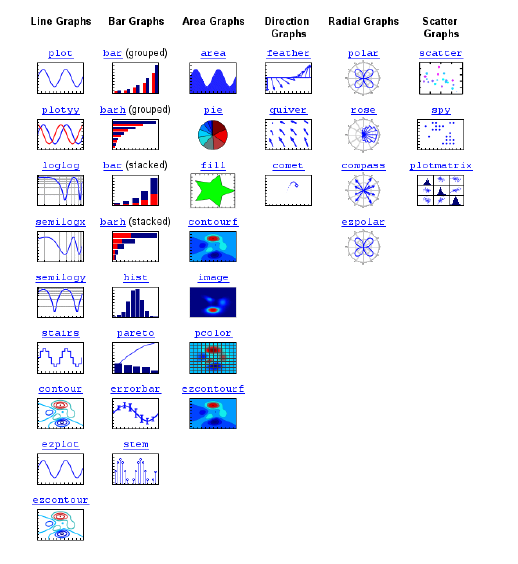

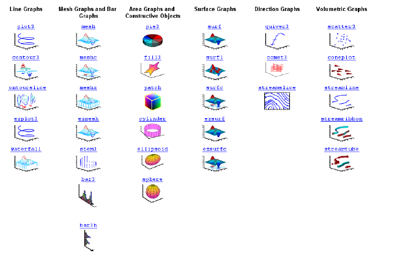

http://www.mathworks.com/help/matlab/creating_plots/types-of-matlab-plots.html

## Line Graphs: plot

The basic MATLAB graphing procedure, for example in 2D, is to take a vector of x-coordinates, x = (x1; ... ; xN), and a vector of y-coordinates, y = (y1; ... ; yN), locate the points (xi; yi), with i = 1; 2; ... ; n and then join them by straight lines. You need to prepare x and y in an identical array form; namely, x and y are both row arrays or column arrays of the same length.

figure(1)

subplot(3,1,1)

x1 = [1 2 3 4 5 6];

y1 = [3 -1 2 4 5 1];

plot(x1,y1)

subplot(3,1,2)

x2 = 0:pi/100:2*pi;

y2 = sin(x2);

plot(x2,y2)

xlabel('x = 0:2\pi')

ylabel('Sine of x')

title('Plot of the Sine function')

subplot(3,1,3)

x3 = 0:pi/10:2*pi;

y31 = 2*cos(x);

y32 = cos(x);

y33 = 0.5*cos(x);

plot(x3,y31,'--rs',x3,y32,'-gd',x3,y33,':bo',...

'LineWidth',2,...

'MarkerEdgeColor','k',...

'MarkerSize',10)

xlabel('0 \leq x \leq 2\pi')

ylabel('Cosine functions')

legend('2*cos(x)','cos(x)','0.5*cos(x)')

title('Typical example of multiple plots')

axis([0 2*pi -3 3])

subplot(3,1,2)

plot(x2,y2,'r:x') % This follows the triplet line style, marker and color (in any order)

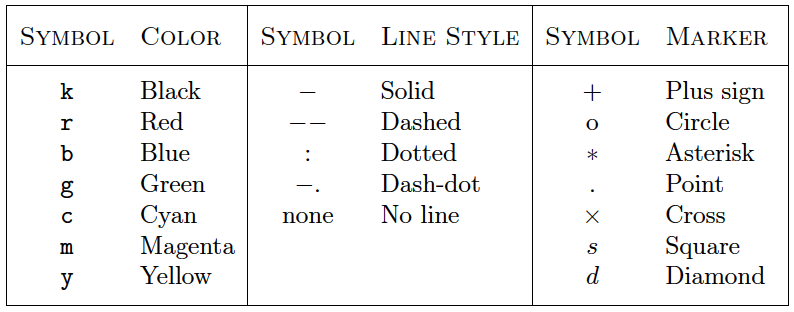

close all

A=[1:10;cos(1:10)]

plot(A)

plot(A')

## Bar Graphs

close all

bar(1:10)

subplot(3,1,1)

bar(magic(5))

subplot(3,1,2)

barh(magic(5))

subplot(3,1,3)

bar(magic(5),'stacked')

barh(magic(5),'stacked')

## 3D Example

The function plot3 is the same as the plot function, but in three dimensions. In addition to this standard three dimensional plot, we can also create surfaces and contour plots.

x=linspace(-5,5);

y=linspace(-5,5);

[X,Y]= meshgrid(x,y);

Z=Y./(1+X.^2+Y.^2);

surf(X,Y,Z)

## 4D Example

load accidents hwydata % load data

long = -hwydata(:,2); % longitude data

lat = hwydata(:,3); % latitude data

rural = 100 - hwydata(:,17); % percent rural data

fatalities = hwydata(:,11); % fatalities data

scatter3(long,lat,rural,40,fatalities,'filled') % draw the scatter plot

xlabel('W. Longitude')

ylabel('N. Latitude')

zlabel('% Rural Population')

cb = colorbar; % create and label the colorbar

cb.Label.String = 'Fatalities per 100M vehicle-miles';